# Bank Churn Prediction - Connie Xavier

## Problem Definition and Information

### Context

Banks have to worry about the problem of 'Churn' i.e. customers leaving and joining another service provider. It is important to understand which aspects of the service influence a customer's decision in this regard. Management can concentrate efforts on the improvement of service, keeping in mind these priorities.

### Objective

Given a Bank customer, build a neural network-based classifier that can determine whether they will leave or not in the next 6 months.

### Key Questions

1. Is there a good neural network model to predict which customers will leave?
2. What are the key factors influencing which customers leave?
3. What improvements can the bank make to keep customers?

### Data Information

Each record in the database represents a customer's information. A detailed data dictionary can be found below.

**Data Dictionary**

- CustomerId: Unique ID which is assigned to each customer
- Surname: Last name of the customer
- CreditScore: It defines the credit history of the customer.
- Geography: A customer’s location
- Gender: It defines the Gender of the customer
- Age: Age of the customer
- Tenure: Number of years for which the customer has been with the bank
- NumOfProducts: It refers to the number of products that a customer has purchased through the bank.
- Balance: Account balance
- HasCrCard: It is a categorical variable that decides whether the customer has a credit card or not.
- EstimatedSalary: Estimated salary
- isActiveMember: It is a categorical variable that decides whether the customer is an active member of the bank or not ( Active member in the sense, using bank products regularly, making transactions, etc )
- Exited: It is a categorical variable that decides whether the customer left the bank within six months or not. It can take two values:
  - 0=No ( Customer did not leave the bank )
  - 1=Yes ( Customer left the bank )

# ----------------------------------------------------------------------------------------

## Part 1: Overview of Data

```python
# import relevant libraries
# this will help in making the Python code more structured automatically (good coding practice)
%load_ext nb_black

# Library to suppress warnings or deprecation notes
import warnings

warnings.filterwarnings("ignore")

# Libraries to help with reading and manipulating data
import pandas as pd
import numpy as np

# libraries to help with visualization
import matplotlib.pyplot as plt
from matplotlib import pyplot
import seaborn as sns

# sklearn libraries
from sklearn.model_selection import train_test_split
from sklearn.preprocessing import StandardScaler, LabelEncoder, OneHotEncoder
from sklearn import model_selection
from sklearn.impute import SimpleImputer
from sklearn import metrics
from sklearn.metrics import roc_curve
from sklearn.metrics import confusion_matrix
from sklearn.model_selection import GridSearchCV
from sklearn.model_selection import RandomizedSearchCV

# tensorflow libraries
import tensorflow as tf
from tensorflow.keras.models import Sequential
from tensorflow.keras.layers import Dense
from tensorflow.keras.layers import Dense, Input, Dropout, BatchNormalization
from tensorflow.keras.wrappers.scikit_learn import KerasClassifier
from tensorflow.keras.optimizers import Adam
from tensorflow.keras.optimizers import RMSprop
from keras import callbacks
from tensorflow import keras
from tensorflow.keras import backend
from tensorflow.keras import layers
from kerastuner.tuners import RandomSearch

# random seed
import random

np.random.seed(1)
tf.random.set_seed(1)
```

```
The nb_black extension is already loaded. To reload it, use:
  %reload_ext nb_black
```

```python
# load the data
data = pd.read_csv("Churn.csv")
```

```python
# check a sample of the data to make sure it came in correctly
data.sample(n=10, random_state=1)
```

|  | RowNumber | CustomerId | Surname | CreditScore | Geography | Gender | Age | Tenure | Balance | NumOfProducts | HasCrCard | IsActiveMember | EstimatedSalary | Exited |
| --- | --- | --- | --- | --- | --- | --- | --- | --- | --- | --- | --- | --- | --- | --- |
| 9953 | 9954 | 15655952 | Burke | 550 | France | Male | 47 | 2 | 0.00 | 2 | 1 | 1 | 97057.28 | 0 |
| 3850 | 3851 | 15775293 | Stephenson | 680 | France | Male | 34 | 3 | 143292.95 | 1 | 1 | 0 | 66526.01 | 0 |
| 4962 | 4963 | 15665088 | Gordon | 531 | France | Female | 42 | 2 | 0.00 | 2 | 0 | 1 | 90537.47 | 0 |
| 3886 | 3887 | 15720941 | Tien | 710 | Germany | Male | 34 | 8 | 147833.30 | 2 | 0 | 1 | 1561.58 | 0 |
| 5437 | 5438 | 15733476 | Gonzalez | 543 | Germany | Male | 30 | 6 | 73481.05 | 1 | 1 | 1 | 176692.65 | 0 |
| 8517 | 8518 | 15671800 | Robinson | 688 | France | Male | 20 | 8 | 137624.40 | 2 | 1 | 1 | 197582.79 | 0 |
| 2041 | 2042 | 15709846 | Yeh | 840 | France | Female | 39 | 1 | 94968.97 | 1 | 1 | 0 | 84487.62 | 0 |
| 1989 | 1990 | 15622454 | Zaitsev | 695 | Spain | Male | 28 | 0 | 96020.86 | 1 | 1 | 1 | 57992.49 | 0 |
| 1933 | 1934 | 15815560 | Bogle | 666 | Germany | Male | 74 | 7 | 105102.50 | 1 | 1 | 1 | 46172.47 | 0 |
| 9984 | 9985 | 15696175 | Echezonachukwu | 602 | Germany | Male | 35 | 7 | 90602.42 | 2 | 1 | 1 | 51695.41 | 0 |

- Looks like all the features came in.
- RowNumber, CustomerId, and Surname will be unique to each customer and do not contain relevant information for the model and can be dropped.
- No missing values appear in this sample section

```python
# check the shape
print(f"There are {data.shape[0]} rows and {data.shape[1]} columns in the data.")
```

```
There are 10000 rows and 14 columns in the data.
```

```python
# check for duplicates in columns that should be unique
print(f"There are {data.RowNumber.duplicated().sum()} duplicated values in RowNumber.")
print(
    f"There are {data.CustomerId.duplicated().sum()} duplicated values in CustomerId."
)
print(f"There are {data.duplicated().sum()} duplicated rows in the data.")
```

```
There are 0 duplicated values in RowNumber.
There are 0 duplicated values in CustomerId.
There are 0 duplicated rows in the data.
```

- Since all values are unique, drop these columns.
- We will drop Surname as well, as that should not be a relevant factor in determining whether or not a person exited.

```python
# drop columns
df = data.copy()
df = df.drop(["RowNumber", "CustomerId", "Surname"], axis=1)
```

```python
# check datatypes of the columns and which columns have null values
df.info()
```

```
<class 'pandas.core.frame.DataFrame'>
RangeIndex: 10000 entries, 0 to 9999
Data columns (total 11 columns):
 #   Column           Non-Null Count  Dtype
---  ------           --------------  -----
 0   CreditScore      10000 non-null  int64
 1   Geography        10000 non-null  object
 2   Gender           10000 non-null  object
 3   Age              10000 non-null  int64
 4   Tenure           10000 non-null  int64
 5   Balance          10000 non-null  float64
 6   NumOfProducts    10000 non-null  int64
 7   HasCrCard        10000 non-null  int64
 8   IsActiveMember   10000 non-null  int64
 9   EstimatedSalary  10000 non-null  float64
 10  Exited           10000 non-null  int64
dtypes: float64(2), int64(7), object(2)
memory usage: 859.5+ KB
```

```python
# check which columns have null values
df.isna().sum()[df.isna().sum() > 0]
```

```
Series([], dtype: int64)
```

- All features have 10,000 values, so there are no null values.
- CreditScore, Age, Tenure, NumOfProducts are correctly classified as int type.
- Balance and EstimatedSalary are correctly classified as float type.
- Geography, Gender should change from object to category data type.
- HasCrCard, IsActiveMember, and Exited should be changed from int to category type.

```python
# check the unique values for the categorical variables
cat_cols = ["Geography", "Gender", "HasCrCard", "IsActiveMember", "Exited"]

for i in cat_cols:
    print(df[i].value_counts(normalize=True))
    print("-" * 50)
```

```
France     0.5014
Germany    0.2509
Spain      0.2477
Name: Geography, dtype: float64
--------------------------------------------------
Male      0.5457
Female    0.4543
Name: Gender, dtype: float64
--------------------------------------------------
1    0.7055
0    0.2945
Name: HasCrCard, dtype: float64
--------------------------------------------------
1    0.5151
0    0.4849
Name: IsActiveMember, dtype: float64
--------------------------------------------------
0    0.7963
1    0.2037
Name: Exited, dtype: float64
--------------------------------------------------
```

- About 20% of customers have churned the bank.
- All customers are either from France, Germany, or Spain.
- All other columns take on an expected range of values.

```python
# convert columns to category type
df[cat_cols] = df[cat_cols].astype("category")
```

```python
# look at the statistical summary of the data
df.describe(include="all").T
```

|  | count | unique | top | freq | mean | std | min | 25% | 50% | 75% | max |
| --- | --- | --- | --- | --- | --- | --- | --- | --- | --- | --- | --- |
| CreditScore | 10000.0 | NaN | NaN | NaN | 650.5288 | 96.653299 | 350.0 | 584.0 | 652.0 | 718.0 | 850.0 |
| Geography | 10000 | 3 | France | 5014 | NaN | NaN | NaN | NaN | NaN | NaN | NaN |
| Gender | 10000 | 2 | Male | 5457 | NaN | NaN | NaN | NaN | NaN | NaN | NaN |
| Age | 10000.0 | NaN | NaN | NaN | 38.9218 | 10.487806 | 18.0 | 32.0 | 37.0 | 44.0 | 92.0 |
| Tenure | 10000.0 | NaN | NaN | NaN | 5.0128 | 2.892174 | 0.0 | 3.0 | 5.0 | 7.0 | 10.0 |
| Balance | 10000.0 | NaN | NaN | NaN | 76485.889288 | 62397.405202 | 0.0 | 0.0 | 97198.54 | 127644.24 | 250898.09 |
| NumOfProducts | 10000.0 | NaN | NaN | NaN | 1.5302 | 0.581654 | 1.0 | 1.0 | 1.0 | 2.0 | 4.0 |
| HasCrCard | 10000.0 | 2.0 | 1.0 | 7055.0 | NaN | NaN | NaN | NaN | NaN | NaN | NaN |
| IsActiveMember | 10000.0 | 2.0 | 1.0 | 5151.0 | NaN | NaN | NaN | NaN | NaN | NaN | NaN |
| EstimatedSalary | 10000.0 | NaN | NaN | NaN | 100090.239881 | 57510.492818 | 11.58 | 51002.11 | 100193.915 | 149388.2475 | 199992.48 |
| Exited | 10000.0 | 2.0 | 0.0 | 7963.0 | NaN | NaN | NaN | NaN | NaN | NaN | NaN |

Significant observations:

- Most customers are from France, are male, have a credit card, are an active member, and didn't exit the bank.
- The mean and median are close in value for CreditScore.
- There's a big gap between 75% and max age, indicating possible outliers.
- Mean and median of tenure are close in value.
- There are a lot of customers with 0 balance as both the min and 25% values are 0.
- Most customers have only 1 product.
- The mean and median of EstimatedSalary are close in value.

## Part 2: Exploratory Data Analysis and Data Preprocessing

Exploratory data analysis and data preprocessing involving missing value and outlier detection and treatment often depend on each other, so they are included together below.

### Univariate Analysis

```python
# function to plot a boxplot and a histogram along the same scale.


def histogram_boxplot(data, feature, figsize=(12, 7), kde=True, bins=None):
    """
    Boxplot and histogram combined

    data: dataframe
    feature: dataframe column
    figsize: size of figure (default (12,7))
    kde: whether to the show density curve (default False)
    bins: number of bins for histogram (default None)
    """
    f2, (ax_box2, ax_hist2) = plt.subplots(
        nrows=2,  # Number of rows of the subplot grid= 2
        sharex=True,  # x-axis will be shared among all subplots
        gridspec_kw={"height_ratios": (0.25, 0.75)},
        figsize=figsize,
    )  # creating the 2 subplots
    sns.boxplot(
        data=data, x=feature, ax=ax_box2, showmeans=True, color="violet"
    )  # boxplot will be created and a star will indicate the mean value of the column
    sns.histplot(
        data=data, x=feature, kde=kde, ax=ax_hist2, bins=bins, palette="winter"
    ) if bins else sns.histplot(
        data=data, x=feature, kde=kde, ax=ax_hist2
    )  # For histogram
    ax_hist2.axvline(
        data[feature].mean(), color="green", linestyle="--"
    )  # Add mean to the histogram
    ax_hist2.axvline(
        data[feature].median(), color="black", linestyle="-"
    )  # Add median to the histogram
```

```python
# function to create labeled barplots


def labeled_barplot(data, feature, perc=False, n=None):
    """
    Barplot with percentage at the top

    data: dataframe
    feature: dataframe column
    perc: whether to display percentages instead of count (default is False)
    n: displays the top n category levels (default is None, i.e., display all levels)
    """

    total = len(data[feature])  # length of the column
    count = data[feature].nunique()
    if n is None:
        plt.figure(figsize=(count + 1, 5))
    else:
        plt.figure(figsize=(n + 1, 5))

    plt.xticks(rotation=90, fontsize=15)
    ax = sns.countplot(
        data=data,
        x=feature,
        palette="Paired",
        order=data[feature].value_counts().index[:n],
    )

    for p in ax.patches:
        if perc == True:
            label = "{:.1f}%".format(
                100 * p.get_height() / total
            )  # percentage of each class of the category
        else:
            label = p.get_height()  # count of each level of the category

        x = p.get_x() + p.get_width() / 2  # width of the plot
        y = p.get_height()  # height of the plot

        ax.annotate(
            label,
            (x, y),
            ha="center",
            va="center",
            size=12,
            xytext=(0, 5),
            textcoords="offset points",
        )  # annotate the percentage

    plt.show()  # show the plot
```

```
CreditScore
```

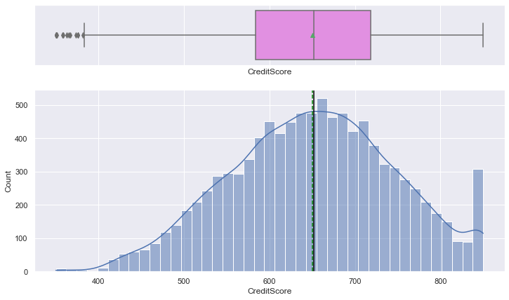

```
Age
```

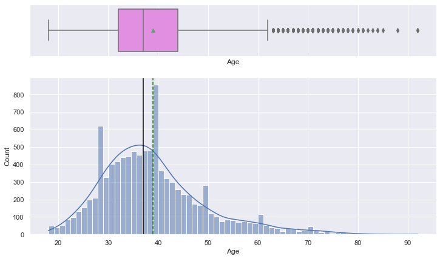

```
Tenure
```

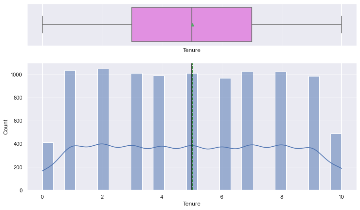

```
Balance
```

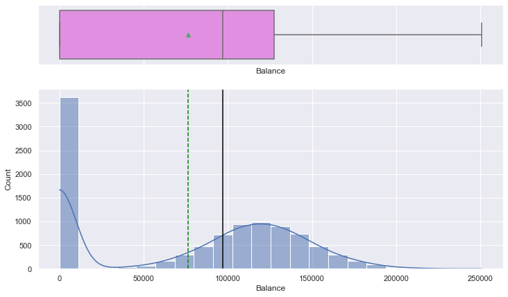

```
NumOfProducts
```

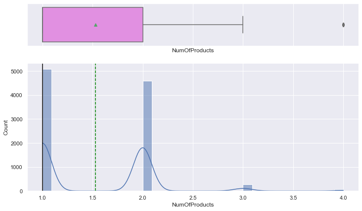

```
EstimatedSalary
```

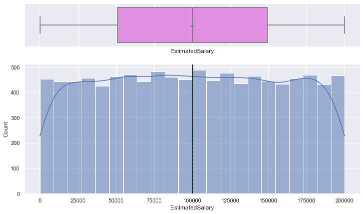

```python
## plot histogram and boxplot for the numerical features
num_cols = list(df.select_dtypes(include=["float", "int"]).columns)
for i in num_cols:
    print(i)
    histogram_boxplot(df, i)
    plt.show()
    print(
        " ****************************************************************** "
    )  ## To create a separator
```

- CreditScore appears normally distributed with the mean close to the median, but there is a huge spike at the high end of the credit score range. There are outliers to the left, but these are within a reasonable range.
- Age is skewed to the right with several outliers to the right. There are some 90+ old customers. Age takes on a reasonable range of values so we will not treat these outliers.
- Tenure appears almost uniformaly distributed, with fewer customers having low or long (10 years) tenure.
- Balance is skewed to the left and has no outliers. There is a high concentration of customers with a 0 bank balance, causing the distribution to skew to the left.
- Most customers hold one or two products with the bank. Very few customers hold 3 or 4 products with the bank.
- EstimatedSalary appears to be uniformally distrubuted, with no sigifniciant peaks or valleys.

```
Geography
```

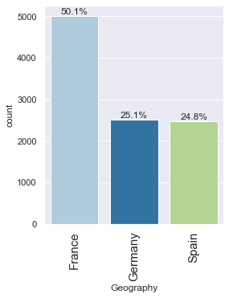

```
Gender
```

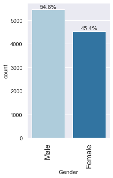

```
HasCrCard
```

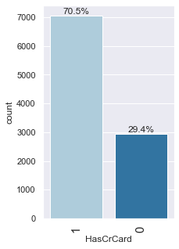

```
IsActiveMember
```

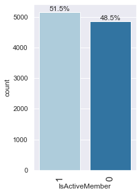

```
Exited
```

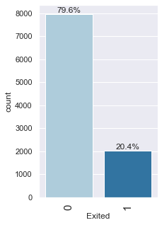

```python
## Barplot for the categorical features
for i in cat_cols:
    print(i)
    labeled_barplot(df, i, perc=True)
    plt.show()
    print(
        " ****************************************************************** "
    )  ## To create a separator
```

- 20.4% have churned bank services, meaning this is a heavily imbalanced dataset.
- There are more male than female customers by about 9%.
- Most (50.1%) of customers are from France, with a fairly even split between Germany and Spain.
- A majority (70.5%) of customers have a credit card.
- A majority (51.5%) of customers are active members.

### Outlier Detection and Treatment

All points fall within a reasonable range, so outliers in the distributions do not need to be treated.

### Bivariate Analysis

Explore relationships between variables.

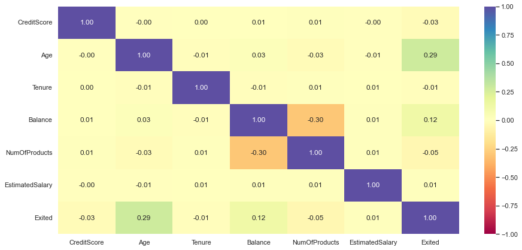

```python
# correlation plot
df["Exited"] = df["Exited"].astype("int")
plt.figure(figsize=(15, 7))
sns.heatmap(df.corr(), annot=True, vmin=-1, vmax=1, fmt=".2f", cmap="Spectral")
plt.show()
```

- No two variables have a very high correlation to each other.
- The highest magnitude correlation is between NumOfProducts and Balance, which has a -0.30 correlation.
- The target variable is most positively correlated with Age, meaning the older a customer is, the more likely the customer will churn bank services.

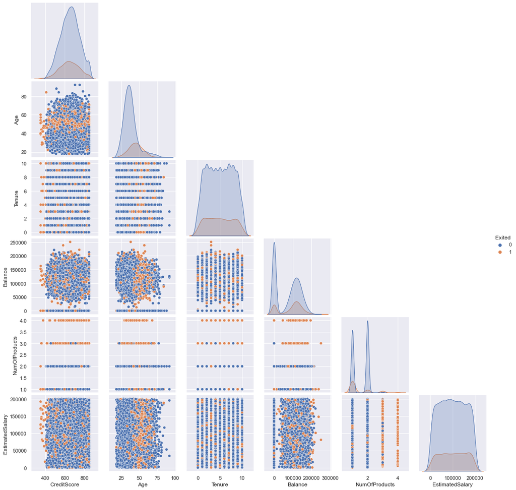

```python
# plot numerical features against each other
sns.pairplot(data=df, hue="Exited", vars=num_cols, corner=True)
plt.show()
```

- There is a lot of overlap in the distributions of customers who exited and those that did not.
- The variables that appear to create some separation in the data is NumOfProducts and Age.

```python
### function to plot distributions wrt target
def distribution_plot_wrt_target(data, predictor, target):

    fig, axs = plt.subplots(2, 2, figsize=(12, 10))

    target_uniq = data[target].unique()

    axs[0, 0].set_title("Distribution of target for target=" + str(target_uniq[0]))
    sns.histplot(
        data=data[data[target] == target_uniq[0]],
        x=predictor,
        kde=True,
        ax=axs[0, 0],
        color="teal",
        stat="density",
    )

    axs[0, 1].set_title("Distribution of target for target=" + str(target_uniq[1]))
    sns.histplot(
        data=data[data[target] == target_uniq[1]],
        x=predictor,
        kde=True,
        ax=axs[0, 1],
        color="orange",
        stat="density",
    )

    axs[1, 0].set_title("Boxplot w.r.t target")
    sns.boxplot(data=data, x=target, y=predictor, ax=axs[1, 0], palette="gist_rainbow")

    axs[1, 1].set_title("Boxplot (without outliers) w.r.t target")
    sns.boxplot(
        data=data,
        x=target,
        y=predictor,
        ax=axs[1, 1],
        showfliers=False,
        palette="gist_rainbow",
    )

    plt.tight_layout()
    plt.show()
```

```python
# function to plot stacked bar chart


def stacked_barplot(data, predictor, target):
    """
    Print the category counts and plot a stacked bar chart

    data: dataframe
    predictor: independent variable
    target: target variable
    """
    count = data[predictor].nunique()
    sorter = data[target].value_counts().index[-1]
    tab1 = pd.crosstab(data[predictor], data[target], margins=True).sort_values(
        by=sorter, ascending=False
    )
    print(tab1)
    print("-" * 120)
    tab = pd.crosstab(data[predictor], data[target], normalize="index").sort_values(
        by=sorter, ascending=False
    )
    tab.plot(kind="bar", stacked=True, figsize=(count + 5, 6))
    plt.legend(
        loc="lower left", frameon=False,
    )
    plt.legend(loc="upper left", bbox_to_anchor=(1, 1))
    plt.show()
```

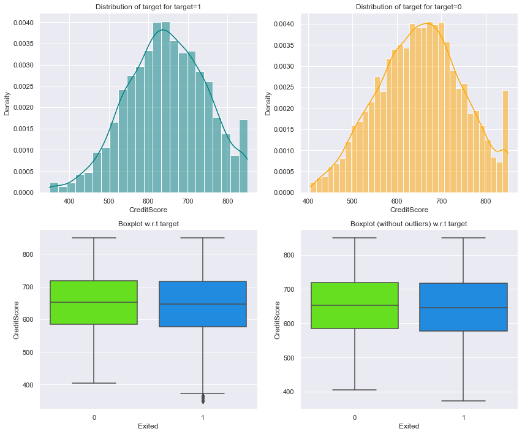

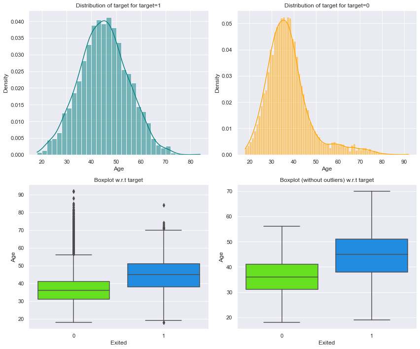

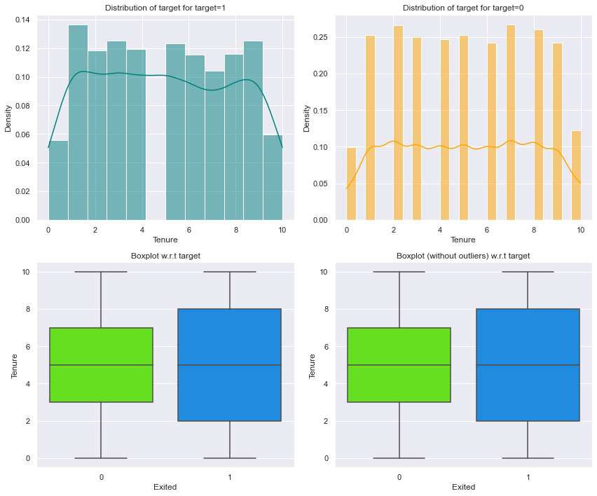

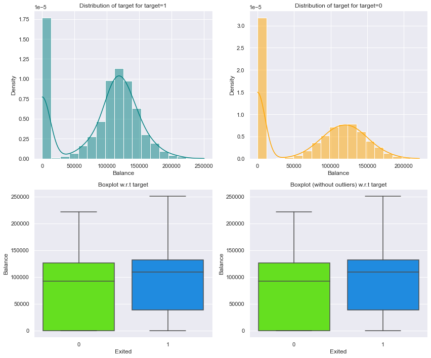

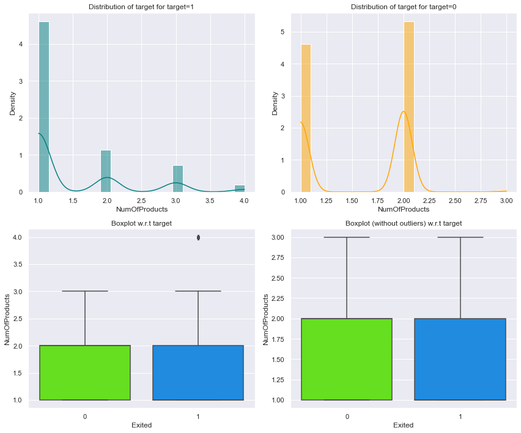

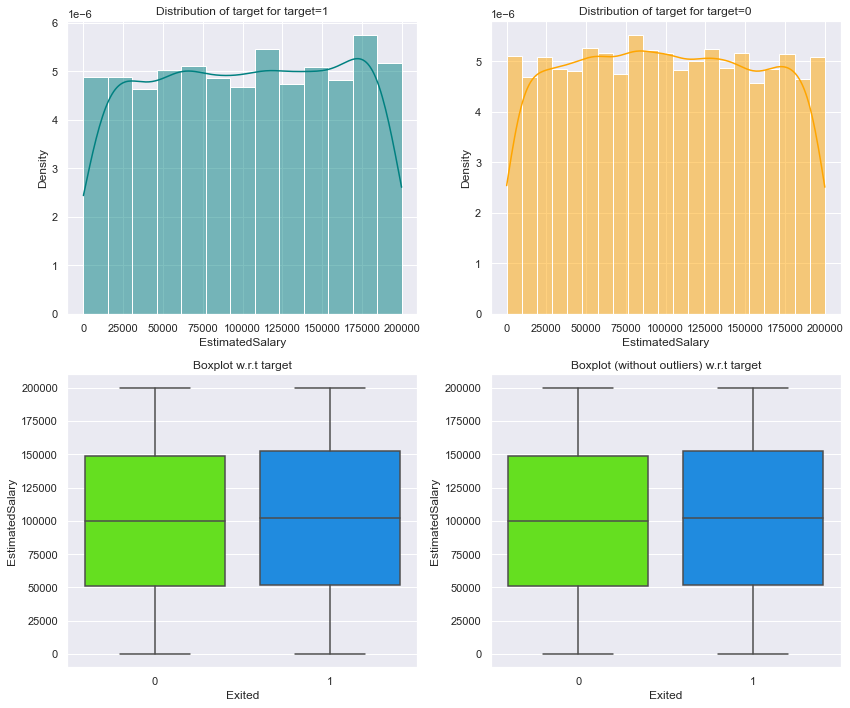

```python
# plot numerical variables with respect to target
sns.set(font_scale=1)
for i in num_cols:
    distribution_plot_wrt_target(df, i, "Exited")
    plt.show()
    print("*" * 100)
```

- Median credit scores are similar between customers who exited and those who did not, except customers who exited make up the lower end of the credit score range.
- Customers who exited have a higher median age than those who did not.
- Customers who exited and those who did not have a similar range of tenure with similar medians. Those who did exit the bank take on a wider interquartile range of tenure years.
- Customers who exited have a higher median balance than those who did not and have a higher bank balance range.
- Customers who exited are more likely to hold a higher number of products (>2) than customers who did not exit. Most of the customers who did not exit hold 1 or 2 products, while a majority of the customers who exited only hold 1 product.
- Customers who did and did not exit have similar EstimatedSalary distributions.

```
Geography
Exited        0     1    All
Geography
All        7963  2037  10000
Germany    1695   814   2509
France     4204   810   5014
Spain      2064   413   2477
------------------------------------------------------------------------------------------------------------------------
```

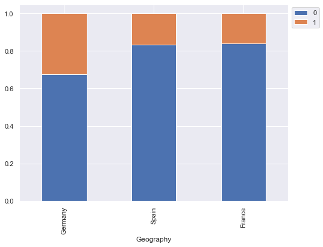

```
Gender
Exited     0     1    All
Gender
All     7963  2037  10000
Female  3404  1139   4543
Male    4559   898   5457
------------------------------------------------------------------------------------------------------------------------
```

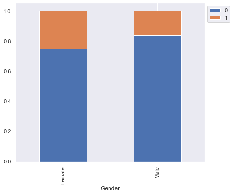

```
HasCrCard
Exited        0     1    All
HasCrCard
All        7963  2037  10000
1          5631  1424   7055
0          2332   613   2945
------------------------------------------------------------------------------------------------------------------------
```

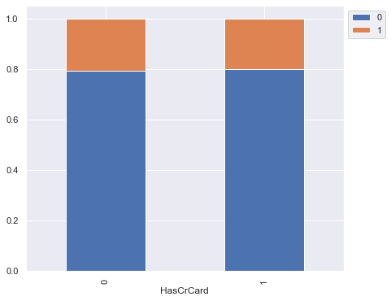

```
IsActiveMember
Exited             0     1    All
IsActiveMember
All             7963  2037  10000
0               3547  1302   4849
1               4416   735   5151
------------------------------------------------------------------------------------------------------------------------
```

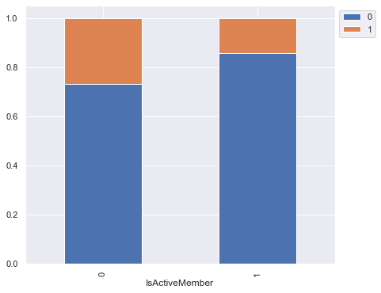

```
NumOfProducts
Exited            0     1    All
NumOfProducts
All            7963  2037  10000
1              3675  1409   5084
2              4242   348   4590
3                46   220    266
4                 0    60     60
------------------------------------------------------------------------------------------------------------------------
```

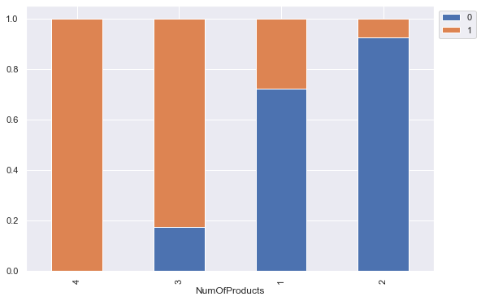

```python
# plot categorical variables with respect to target
othercols = cat_cols.copy()
othercols.append("NumOfProducts")
othercols.remove("Exited")
for i in othercols:
    print(i)
    stacked_barplot(df, i, "Exited")
    plt.show()
    print(
        " ****************************************************************** "
    )  ## To create a separator
```

- Customers from Germany are more likely to exit than customers from Spain or France.
- More female than male customers exited.
- Customers who do or don't have a credit card have a similar probability of exiting. We could remove this variable from the analysis if wanted.
- Customers who are not active members of the bank are more likely to exit the bank.
- Customers who hold 3 or 4 products are more likely to exit the bank. Customers who hold 1 product are more likely to exit than customers who hold two products with the bank.

```python
# explore the variables that did not show much difference between customers who exited and those who did not
# filter for customers who did not exit
df[df.Exited == 0][["EstimatedSalary"]].describe(include="all").T
```

|  | count | mean | std | min | 25% | 50% | 75% | max |
| --- | --- | --- | --- | --- | --- | --- | --- | --- |
| EstimatedSalary | 7963.0 | 99738.391772 | 57405.586966 | 90.07 | 50783.49 | 99645.04 | 148609.955 | 199992.48 |

```python
# filter for customers who did exit
df[df.Exited == 1][["EstimatedSalary"]].describe().T
```

|  | count | mean | std | min | 25% | 50% | 75% | max |
| --- | --- | --- | --- | --- | --- | --- | --- | --- |
| EstimatedSalary | 2037.0 | 101465.677531 | 57912.418071 | 11.58 | 51907.72 | 102460.84 | 152422.91 | 199808.1 |

- The data shows that customers who exited have a slightly higher mean and median value than those who did not exit, but the spread of the distributions are similar.

### Splitting data

```python
## Separating Independent and Dependent Columns
df1 = df.copy()
X = df1.drop(["Exited"], axis=1)
y = df1[["Exited"]]
```

```python
# Splitting data into training, validation and test set:
# first we split data into 2 parts, say temporary and test

X_temp, X_test, y_temp, y_test = train_test_split(
    X, y, test_size=0.2, random_state=1, stratify=y
)

# then we split the temporary set into train and validation

X_train, X_val, y_train, y_val = train_test_split(
    X_temp, y_temp, test_size=0.25, random_state=1, stratify=y_temp
)
print(X_train.shape, X_val.shape, X_test.shape)
```

```
(6000, 10) (2000, 10) (2000, 10)
```

### Normalizing the data

```python
## Scaling the data to get all variables in similar scale
sc = StandardScaler()
stdcols = X_train.select_dtypes(include=["int", "float"]).columns
temp = sc.fit(X_train[stdcols])
X_train[stdcols] = temp.transform(X_train[stdcols])
X_test[stdcols] = temp.transform(X_test[stdcols])
X_val[stdcols] = temp.transform(X_val[stdcols])
```

### Encoding Categorical Columns

```python
# Using pd.get dummies to encode the categorical columns in the data
cat_data = cat_cols.copy()
cat_data.remove("Exited")
X_train = pd.get_dummies(X_train, columns=cat_data, drop_first=True)
X_test = pd.get_dummies(X_test, columns=cat_data, drop_first=True)
X_val = pd.get_dummies(X_val, columns=cat_data, drop_first=True)
```

```python
# Checking the shape to make sure dimensions are equal
print("Datasets - x")
print(X_train.shape)
print(X_val.shape)
print(X_test.shape)
print("Datasets - y")
print(y_train.shape)
print(y_val.shape)
print(y_test.shape)
```

```
Datasets - x
(6000, 11)
(2000, 11)
(2000, 11)
Datasets - y
(6000, 1)
(2000, 1)
(2000, 1)
```

```python
# check sample of training data
X_train.head()
```

|  | CreditScore | Age | Tenure | Balance | NumOfProducts | EstimatedSalary | Geography_Germany | Geography_Spain | Gender_Male | HasCrCard_1 | IsActiveMember_1 |
| --- | --- | --- | --- | --- | --- | --- | --- | --- | --- | --- | --- |
| 4472 | 0.091585 | -1.519034 | 0.351144 | 1.447084 | 0.786577 | -0.173839 | 1 | 0 | 0 | 0 | 0 |
| 4034 | -0.516304 | 0.279984 | -0.336475 | 0.340252 | -0.915356 | 1.713093 | 0 | 1 | 0 | 1 | 1 |
| 1454 | -1.340560 | -0.477497 | 0.694954 | -0.075495 | -0.915356 | -1.392789 | 0 | 1 | 0 | 1 | 1 |
| 9099 | 0.895235 | -0.950923 | -1.024094 | -1.205076 | 0.786577 | 1.212999 | 0 | 0 | 1 | 1 | 1 |
| 2489 | 0.647958 | -1.045608 | 0.351144 | 0.754843 | -0.915356 | -0.580512 | 0 | 0 | 1 | 1 | 1 |

- All variables are now in a similar scale.

```python
# check y values
y_train.head()
```

|  | Exited |
| --- | --- |
| 4472 | 0 |
| 4034 | 0 |
| 1454 | 1 |
| 9099 | 0 |
| 2489 | 0 |

```python
print("Split of 0 and 1 in training data:\n", y_train.value_counts(normalize=True))
print("Split of 0 and 1 in validation data:\n", y_val.value_counts(normalize=True))
print("Split of 0 and 1 in test data:\n", y_test.value_counts(normalize=True))
```

```
Split of 0 and 1 in training data:
 Exited
0         0.796333
1         0.203667
dtype: float64
Split of 0 and 1 in validation data:
 Exited
0         0.796
1         0.204
dtype: float64
Split of 0 and 1 in test data:
 Exited
0         0.7965
1         0.2035
dtype: float64
```

- Split of 0 and 1 is similar across the sets.

## Part 3: Model Evaluation

### Model evaluation criterion:

#### Model can make wrong predictions as:

1. Predicting a customer will exit the bank but in reality, the customer is not going to do that - Loss of resources
2. Predicting a customer will not exit the bank but the customer will - Loss of revenue

#### Which case is more important?

- Predicting a customer will not exit the bank but the customer does would be more detrimental to the busines since that will be a loss in revenue for the company.

### How to reduce this loss?

- `recall` should be maximized, the greater the recall higher the chances of minimizing the false negatives.

```python
def make_confusion_matrix(
    cf,
    group_names=None,
    categories="auto",
    count=True,
    percent=True,
    cbar=True,
    xyticks=True,
    xyplotlabels=True,
    sum_stats=True,
    figsize=None,
    cmap="Blues",
    title=None,
):
    """
    This function will make a pretty plot of an sklearn Confusion Matrix cm using a Seaborn heatmap visualization.
    Arguments
    """

    # CODE TO GENERATE TEXT INSIDE EACH SQUARE
    blanks = ["" for i in range(cf.size)]

    if group_names and len(group_names) == cf.size:
        group_labels = ["{}\n".format(value) for value in group_names]
    else:
        group_labels = blanks

    if count:
        group_counts = ["{0:0.0f}\n".format(value) for value in cf.flatten()]
    else:
        group_counts = blanks

    if percent:
        group_percentages = [
            "{0:.2%}".format(value) for value in cf.flatten() / np.sum(cf)
        ]
    else:
        group_percentages = blanks

    box_labels = [
        f"{v1}{v2}{v3}".strip()
        for v1, v2, v3 in zip(group_labels, group_counts, group_percentages)
    ]
    box_labels = np.asarray(box_labels).reshape(cf.shape[0], cf.shape[1])

    # CODE TO GENERATE SUMMARY STATISTICS & TEXT FOR SUMMARY STATS
    if sum_stats:
        # Accuracy is sum of diagonal divided by total observations
        accuracy = np.trace(cf) / float(np.sum(cf))

        # if it is a binary confusion matrix, show some more stats
        if len(cf) == 2:
            # Metrics for Binary Confusion Matrices
            precision = cf[1, 1] / sum(cf[:, 1])
            recall = cf[1, 1] / sum(cf[1, :])
            f1_score = 2 * precision * recall / (precision + recall)
            stats_text = "\n\nAccuracy={:0.3f}\nPrecision={:0.3f}\nRecall={:0.3f}\nF1 Score={:0.3f}".format(
                accuracy, precision, recall, f1_score
            )
        else:
            stats_text = "\n\nAccuracy={:0.3f}".format(accuracy)
    else:
        stats_text = ""

    # SET FIGURE PARAMETERS ACCORDING TO OTHER ARGUMENTS
    if figsize == None:
        # Get default figure size if not set
        figsize = plt.rcParams.get("figure.figsize")

    if xyticks == False:
        # Do not show categories if xyticks is False
        categories = False

    # MAKE THE HEATMAP VISUALIZATION
    plt.figure(figsize=figsize)
    sns.heatmap(
        cf,
        annot=box_labels,
        fmt="",
        cmap=cmap,
        cbar=cbar,
        xticklabels=categories,
        yticklabels=categories,
    )

    if xyplotlabels:
        plt.ylabel("True label")
        plt.xlabel("Predicted label" + stats_text)
    else:
        plt.xlabel(stats_text)

    if title:
        plt.title(title)


def stats(cf, sum_stats=True):
    # CODE TO GENERATE SUMMARY STATISTICS & TEXT FOR SUMMARY STATS
    if sum_stats:
        # Accuracy is sum of diagonal divided by total observations
        accuracy = np.trace(cf) / float(np.sum(cf))

        # if it is a binary confusion matrix, show some more stats
        if len(cf) == 2:
            # Metrics for Binary Confusion Matrices
            precision = cf[1, 1] / sum(cf[:, 1])
            recall = cf[1, 1] / sum(cf[1, :])
            f1_score = 2 * precision * recall / (precision + recall)
        else:
            stats_text = "\n\nAccuracy={:0.3f}".format(accuracy)
    else:
        stats_text = ""
    # creating a dataframe of metrics
    df_perf = pd.DataFrame(
        {
            "Accuracy": accuracy,
            "Recall": recall,
            "Precision": precision,
            "F1": f1_score,
        },
        index=[0],
    )

    return df_perf
```

# Part 4: Model Building

### Model 1

```python
backend.clear_session()
# Fixing the seed for random number generators so that we can ensure we receive the same output everytime
np.random.seed(1)
random.seed(1)
tf.random.set_seed(1)
```

```python
# Initializing the ANN
model1 = Sequential()
# This adds the input layer (by specifying input dimension) AND the first hidden layer (units)
model1.add(
    Dense(
        activation="relu",
        kernel_initializer="he_uniform",
        input_dim=X_train.shape[1],
        units=64,
    )
)
# Add hidden layer
model1.add(Dense(32, activation="relu", kernel_initializer="he_uniform"))
# Adding the output layer
# We use the sigmod because we want probability outcomes
model1.add(Dense(1, activation="sigmoid"))
# Initializing the Optimizer
optimizer = RMSprop(learning_rate=0.001)
# Compiling the model with loss function and metrics
model1.compile(loss="binary_crossentropy", optimizer=optimizer, metrics=["accuracy"])
```

```python
# output model dimensions and parameters
model1.summary()
```

```
Model: "sequential"
_________________________________________________________________
 Layer (type)                Output Shape              Param #
=================================================================
 dense (Dense)               (None, 64)                768

 dense_1 (Dense)             (None, 32)                2080

 dense_2 (Dense)             (None, 1)                 33

=================================================================
Total params: 2,881
Trainable params: 2,881
Non-trainable params: 0
_________________________________________________________________
```

```python
# Fitting the model on train and validation with 50 epochs
history1 = model1.fit(
    X_train, y_train, validation_data=(X_val, y_val), batch_size=32, epochs=50
)
```

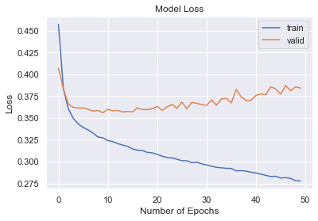

```python
# Capturing learning history per epoch
hist = pd.DataFrame(history1.history)
hist["epoch"] = history1.epoch

# Plotting accuracy at different epochs
plt.plot(hist["loss"])
plt.plot(hist["val_loss"])
plt.legend(("train", "valid"), loc=0)
plt.xlabel("Number of Epochs")
plt.ylabel("Loss")
plt.title("Model Loss")

# Printing results
results = model1.evaluate(X_val, y_val)
```

- Here the model seems to be overfitting, as the distance between the training curve and validation curve started increasing.
- There is also some noise in the validation data.

```python
# convert probabilities to predictions using 0.5 threshold
y_pred = model1.predict(X_val)
y_pred = y_pred > 0.5
```

```
              precision    recall  f1-score   support

           0       0.88      0.92      0.90      1592
           1       0.64      0.53      0.58       408

    accuracy                           0.84      2000
   macro avg       0.76      0.73      0.74      2000
weighted avg       0.83      0.84      0.84      2000
```

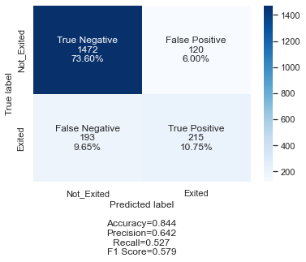

```python
# Calculating the confusion matrix
cm = confusion_matrix(y_val, y_pred)
cm_r = stats(cm)
labels = ["True Negative", "False Positive", "False Negative", "True Positive"]
categories = ["Not_Exited", "Exited"]
make_confusion_matrix(cm, group_names=labels, categories=categories, cmap="Blues")
# Accuracy as per the classification report
cr = metrics.classification_report(y_val, y_pred)
print(cr)
```

- There is 9.65% False Negatives. We gave 0.5 as the threshold to the model, and as this is an imbalanced dataset, we should calculate the threshold using the AUC-ROC curve.
- The model shows good overall accuracy (84%), but low recall on the true positives. There could be a few reasons:

1) **Imbalanced dataset**: As seen in the EDA, this dataset is imbalanced, and it contains more examples that belong to the **0** class.

2) **Decision Threshold**: Due to the imbalanced dataset, we can use ROC-AUC to find the optimal threshold and use the same for prediction.

Let's try to change the optimizer, tune the decision threshold, increase the layers and configure some other hyperparameters accordingly, in order to improve the model's performance.

```
Best Threshold=0.256984, G-Mean=0.837
```

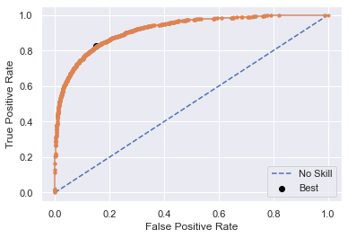

```python
# change threshold using ROC-AUC curve.
# predict probabilities
yhat1 = model1.predict(X_train)
# keep probabilities for the positive outcome only
yhat1 = yhat1[:, 0]
# calculate roc curves
fpr, tpr, thresholds1 = roc_curve(y_train, yhat1)
# calculate the g-mean for each threshold
# g-mean is a metric for imbalanced classification that, if optimized, will seek a balance between the sensitivity and the specificity.
gmeans1 = np.sqrt(tpr * (1 - fpr))
# locate the index of the largest g-mean
ix = np.argmax(gmeans1)
print("Best Threshold=%f, G-Mean=%.3f" % (thresholds1[ix], gmeans1[ix]))
# plot the roc curve for the model
pyplot.plot([0, 1], [0, 1], linestyle="--", label="No Skill")
pyplot.plot(fpr, tpr, marker=".")
pyplot.scatter(fpr[ix], tpr[ix], marker="o", color="black", label="Best")
# axis labels
pyplot.xlabel("False Positive Rate")
pyplot.ylabel("True Positive Rate")
pyplot.legend()
# show the plot
pyplot.show()
```

```python
# Predicting the results using best as a threshold
y_pred_e1 = model1.predict(X_val)
y_pred_e1 = y_pred_e1 > thresholds1[ix]
```

```
              precision    recall  f1-score   support

           0       0.92      0.82      0.87      1592
           1       0.51      0.72      0.60       408

    accuracy                           0.80      2000
   macro avg       0.71      0.77      0.73      2000
weighted avg       0.84      0.80      0.81      2000
```

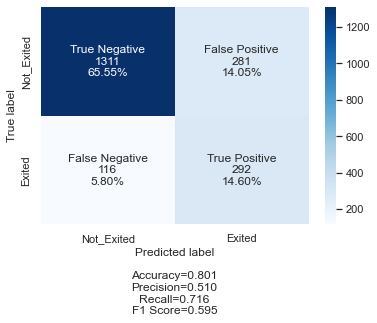

```python
# Calculating the confusion matrix
cm1 = confusion_matrix(y_val, y_pred_e1)
cm1_r = stats(cm1)
labels = ["True Negative", "False Positive", "False Negative", "True Positive"]
categories = ["Not_Exited", "Exited"]
make_confusion_matrix(cm1, group_names=labels, categories=categories, cmap="Blues")
# Accuracy as per the classification report
cr1 = metrics.classification_report(y_val, y_pred_e1)
print(cr1)
```

- The recall score has increased for "1" from 0.53 to 0.72.
- Overall accuracy has dropped from 0.84 to 0.80.
- False negatives have decreased while False Positives have increased.

We will try to increase recall scores and decrease noise and overfitting. For the next model, we will try using batch normalization, add a hidden layer, and change the optimizer from RMSprop to Adam.

### Model 2

```python
backend.clear_session()
np.random.seed(1)
random.seed(1)
tf.random.set_seed(1)
```

```python
model2 = Sequential()
# Adding the hidden and output layers
model2.add(
    Dense(
        64,
        activation="relu",
        kernel_initializer="he_uniform",
        input_dim=X_train.shape[1],
    )
)
model2.add(BatchNormalization())
model2.add(Dense(32, activation="relu", kernel_initializer="he_uniform"))
model2.add(BatchNormalization())
model2.add(Dense(16, activation="relu", kernel_initializer="he_uniform"))
model2.add(BatchNormalization())
model2.add(Dense(1, activation="sigmoid"))
# Compiling the ANN with Adam optimizer and binary cross entropy loss function
optimizer = tf.keras.optimizers.Adam(0.001)
model2.compile(loss="binary_crossentropy", optimizer=optimizer, metrics=["accuracy"])
```

```python
model2.summary()
```

```
Model: "sequential"
_________________________________________________________________
 Layer (type)                Output Shape              Param #
=================================================================
 dense (Dense)               (None, 64)                768

 batch_normalization (BatchN  (None, 64)               256
 ormalization)

 dense_1 (Dense)             (None, 32)                2080

 batch_normalization_1 (Batc  (None, 32)               128
 hNormalization)

 dense_2 (Dense)             (None, 16)                528

 batch_normalization_2 (Batc  (None, 16)               64
 hNormalization)

 dense_3 (Dense)             (None, 1)                 17

=================================================================
Total params: 3,841
Trainable params: 3,617
Non-trainable params: 224
_________________________________________________________________
```

```python
# Fitting the model on train and validation with 50 epochs
history2 = model2.fit(
    X_train, y_train, batch_size=32, validation_data=(X_val, y_val), epochs=50
)
```

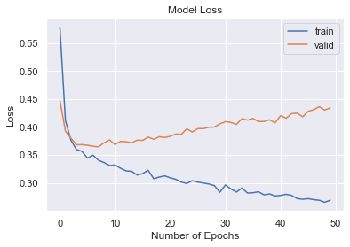

```python
# Capturing learning history per epoch
hist = pd.DataFrame(history2.history)
hist["epoch"] = history2.epoch

# Plotting accuracy at different epochs
plt.plot(hist["loss"])
plt.plot(hist["val_loss"])
plt.legend(("train", "valid"), loc=0)
plt.xlabel("Number of Epochs")
plt.ylabel("Loss")
plt.title("Model Loss")

# Printing results
results = model2.evaluate(X_val, y_val)
```

- The changes did not seem to help much as there is more noise now in the training data and still overfitting.

```
Best Threshold=0.202375, G-Mean=0.882
```

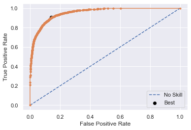

```python
# change threshold using ROC-AUC curve.
# predict probabilities
yhat1 = model2.predict(X_train)
# keep probabilities for the positive outcome only
yhat1 = yhat1[:, 0]
# calculate roc curves
fpr, tpr, thresholds1 = roc_curve(y_train, yhat1)
# calculate the g-mean for each threshold
# g-mean is a metric for imbalanced classification that, if optimized, will seek a balance between the sensitivity and the specificity.
gmeans1 = np.sqrt(tpr * (1 - fpr))
# locate the index of the largest g-mean
ix = np.argmax(gmeans1)
print("Best Threshold=%f, G-Mean=%.3f" % (thresholds1[ix], gmeans1[ix]))
# plot the roc curve for the model
pyplot.plot([0, 1], [0, 1], linestyle="--", label="No Skill")
pyplot.plot(fpr, tpr, marker=".")
pyplot.scatter(fpr[ix], tpr[ix], marker="o", color="black", label="Best")
# axis labels
pyplot.xlabel("False Positive Rate")
pyplot.ylabel("True Positive Rate")
pyplot.legend()
# show the plot
pyplot.show()
```

```
              precision    recall  f1-score   support

           0       0.90      0.80      0.85      1592
           1       0.45      0.64      0.53       408

    accuracy                           0.77      2000
   macro avg       0.67      0.72      0.69      2000
weighted avg       0.81      0.77      0.78      2000
```

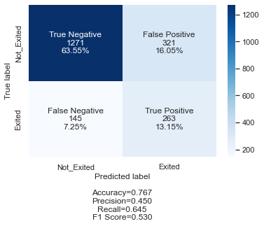

```python
# Predicting the results using best as a threshold
y_pred_e2 = model2.predict(X_val)
y_pred_e2 = y_pred_e2 > thresholds1[ix]
# Calculating the confusion matrix
cm2 = confusion_matrix(y_val, y_pred_e2)
cm2_r = stats(cm2)
labels = ["True Negative", "False Positive", "False Negative", "True Positive"]
categories = ["Not_Exited", "Exited"]
make_confusion_matrix(cm2, group_names=labels, categories=categories, cmap="Blues")
# Accuracy as per the classification report
cr2 = metrics.classification_report(y_val, y_pred_e2)
print(cr2)
```

- Accuracy and recall is lower than the previous model.
- Due to the amount of noise, we will decrease the number of neurons and use Dropout to decrease overfitting.
- We will also increase the number of epochs and add early stopping to force the model to stop so the difference in loss for training and validation does not increase.